# Wildfire Notable-Event Prediction Final Project

## Abstract

A predictive modeling technique for anticipating significant wildfire events one month ahead of time is presented in this research. The objective is to predict if at least one significant wildfire will occur in each spatial grid cell in the upcoming month by averaging the data into grid-by-month observations using previous wildfire occurrence records.

The original incidents data are processed into temporal units and combined with designed predictors that summarize recent wildfire activity, seasonal patterns, and spatial position in order to create the modeling dataset. Both short-term fire persistence and longer-term geographic variability in the occurrence of wildfires are captured by these predictors.

A baseline logistic regression model and a gradient-boosted tree model using XGBoost are the two prediction models that are assessed. Expanding-window, time-aware validation is used to evaluate model performance while maintaining the temporal ordering of the data. The area under the ROC curve (AUC) is the main evaluation statistic due to the relatively small number of wildfire incidents.

The results show that XGBoost achieves stronger predictive performance than the logistic regression baseline. The average validation AUC for XGBoost is 0.784, compared with 0.695 for logistic regression, representing an absolute improvement of approximately 0.0897 AUC points. This suggests that nonlinear models are better able to capture complex relationships in wildfire occurrence data.

```r
suppressMessages({
    library(dplyr)
    library(ggplot2)
    library(tidyverse)
    library(slider)
    library(pROC)
    library(xgboost)
    library(Matrix)
    library(zoo)
})
```

## 1. Data Preprocessing

This section explains how the raw wildfire incident table is converted into a grid-by-month dataset suitable for prediction.

We cover:

- How **notable** fires are identified and filtered
- How **space–time units** are constructed (grid × month)
- How the **binary outcome** is defined
- How **predictors** are constructed (lagged to avoid leakage)
- How missing data / edge cases are handled

### Goal

Create a *modeling-ready* dataset with one row per **(grid cell, month)** and a binary outcome:

> **Outcome** $Y_{g,t}$: whether at least one *notable* fire occurs in **grid cell $g$** in **month $t+1$**.

This “next month” target avoids same-month leakage and matches the project objective of near-future prediction.

### Load Data

Key variable definitions (USDA Forest Service metadata):

- `FIRE_YEAR`: Calendar year the fire was discovered
- `DISCOVERY_DOY`: Day-of-year the fire was discovered
- `FIRE_SIZE`: Final fire size (acres)
- `LATITUDE`, `LONGITUDE`: Ignition location (decimal degrees)
- `STATE`: State in which the fire burned

```r
wildfires <- read_csv("wildfires_sample_100k.csv", show_col_types = FALSE) %>%
  select(FIRE_YEAR, DISCOVERY_DOY, FIRE_SIZE, LATITUDE, LONGITUDE, STATE) %>%
  mutate(STATE = as.factor(STATE))
```

The raw dataset contains 100000 sampled wildfire records that include results of key variables `FIRE_YEAR`, `DISCOVERY_DOY`, `FIRE_SIZE`, `LATITUDE`, `LONGITUDE`, and `STATE`.

### Temporal patterns

Convert `FIRE_YEAR` and `DISCOVERY_DOY` to `FIRE_DATE`.

```r
fires <- wildfires %>%
    mutate(FIRE_DATE = as.Date(paste(FIRE_YEAR, DISCOVERY_DOY, sep = "-"), format = "%Y-%j"),
          YEAR = year(FIRE_DATE),
          MONTH = month(FIRE_DATE))
```

### Notable fire threshold

We define “notable” fires as those with final size **$\ge 300$ acres**, which aligns with commonly used operational reporting thresholds for large fires (e.g., 100 acres in timber, 300 acres in grass/brush).

```r
notable_threshold_acres <- 300


 notable_fires <- fires %>%
    filter(FIRE_SIZE >= notable_threshold_acres)


cat("Number of notable fires:", nrow(notable_fires))
```

```
Number of notable fires: 1381
```

### Spatial patterns

We use a coarse latitude–longitude grid for a spatial unit: **1° × 1° grid**. Convert **event-level fire records** into **a grid × month summary** with a binary indicator. Note that the records here **only** contain fire events, i.e., $Y_{g,t-1}=1$. See `fire_this_month` for the corresponding fire indicator.

```r
notable_fires <- notable_fires %>%
  mutate(
    lat_bin = floor(LATITUDE),
    lon_bin = floor(LONGITUDE),
    ym = YEAR * 100 + MONTH
  )


grid_month_fire <- notable_fires %>%
  group_by(lat_bin, lon_bin, ym) %>%
  summarise(fire_this_month = 1,n_fires = n(), .groups = "drop")

head(grid_month_fire)
```

A tibble: 6 × 5

| lat_bin <dbl> | lon_bin <dbl> | ym <dbl> | fire_this_month <dbl> | n_fires <int> |
| --- | --- | --- | --- | --- |
| 17 | -67 | 200407 | 1 | 1 |
| 18 | -68 | 200906 | 1 | 1 |
| 18 | -67 | 200503 | 1 | 1 |
| 19 | -156 | 199210 | 1 | 1 |
| 19 | -156 | 199910 | 1 | 1 |
| 19 | -156 | 200706 | 1 | 1 |

For reduce extreme sparsity, the panel should limit the grid cells with at least one notable fire record during the time. So, rather than compare across all grid cells, the prediction work should be the occurrence of wildfires in historically fire-active grid cells over the next month.

Next, we construct the **complete (grid, month) panel**. We include both positive (fire) and negative (no-fire) observations for:

- All grid cells that have ever recorded at least one notable fire in `grid_month_fire`, and
- All months within the observed study period., i.e.,the range of `ym`.

This helps create a completed panel with the selected grids, because the predictions are highly imbalanced:grid-month observations is 0.89% have `y_next = 1`, whereas 146,265 observations is 99.11% have `y_next = 0`. It shows that the notable fire events seldom happen.

```r
all_grids <- grid_month_fire %>% distinct(lat_bin, lon_bin)

start_date <- ymd(paste0(min(grid_month_fire$ym) %/% 100, "-", min(grid_month_fire$ym) %% 100, "-01"))
end_date   <- ymd(paste0(max(grid_month_fire$ym) %/% 100, "-", max(grid_month_fire$ym) %% 100, "-01"))

all_months <- tibble(date = seq.Date(start_date, end_date, by = "month")) %>%
  mutate(year = year(date), month = month(date), ym = year * 100 + month) %>%
  select(ym, year, month)


 panel <- crossing(all_grids, all_months) %>%
  left_join(grid_month_fire, by = c("lat_bin", "lon_bin", "ym")) %>%
  mutate(fire_this_month = ifelse(is.na(fire_this_month), 0, fire_this_month),
         n_fires = ifelse(is.na(n_fires), 0, n_fires))



glimpse(panel)
```

```
Rows: 148,092
Columns: 7
$ lat_bin         <dbl> 17, 17, 17, 17, 17, 17, 17, 17, 17, 17, 17, 17, 17, 17…
$ lon_bin         <dbl> -67, -67, -67, -67, -67, -67, -67, -67, -67, -67, -67,…
$ ym              <dbl> 199201, 199202, 199203, 199204, 199205, 199206, 199207…
$ year            <dbl> 1992, 1992, 1992, 1992, 1992, 1992, 1992, 1992, 1992, …
$ month           <dbl> 1, 2, 3, 4, 5, 6, 7, 8, 9, 10, 11, 12, 1, 2, 3, 4, 5, …
$ fire_this_month <dbl> 0, 0, 0, 0, 0, 0, 0, 0, 0, 0, 0, 0, 0, 0, 0, 0, 0, 0, …
$ n_fires         <dbl> 0, 0, 0, 0, 0, 0, 0, 0, 0, 0, 0, 0, 0, 0, 0, 0, 0, 0, …
```

### Prediction target

For each (grid,month), define the indicator for the fire in the next month, i.e., $Y_{g,t}$:

- `y_next = 1` if a notable fire occurs in that grid cell in the next month
- `y_next = 0` otherwise

```r
panel <- panel %>%
  arrange(lat_bin, lon_bin, ym) %>%
  group_by(lat_bin, lon_bin) %>%
  mutate(
    y_next = lead(fire_this_month, n = 1L)
  ) %>%
  ungroup() %>%
  filter(!is.na(y_next))

table(panel$y_next)
```

```
     0      1
146265   1311
```

### Baseline predictors

#### Administrative information: `state`

If multiple states appear within a grid, choose the majority state.

```r
mode_state <- function(x) {
  ux <- unique(x)
  ux[which.max(tabulate(match(x, ux)))]
}

grid_state <- notable_fires %>%
  group_by(lat_bin, lon_bin) %>%
  summarise(state = mode_state(STATE), .groups = "drop")



panel <- panel %>%
  left_join(grid_state, by = c("lat_bin","lon_bin"))

panel %>% select('state') %>% summary
```

```
     state
 AK     :17732
 TX     :16016
 CA     :10582
 MT     : 8294
 NM     : 8294
 OR     : 6578
 (Other):80080
```

#### Seasonality: Cyclical month encoding

Reason: December (12) and January (1) are close in reality, but far numerically.

```r
panel <- panel %>% mutate(
  month_sin = sin(2 * pi * month / 12),
  month_cos = cos(2 * pi * month / 12)
)



panel %>% select('month_sin', 'month_cos') %>% head
```

A tibble: 6 × 2

| month_sin <dbl> | month_cos <dbl> |
| --- | --- |
| 5.000000e-01 | 8.660254e-01 |
| 8.660254e-01 | 5.000000e-01 |
| 1.000000e+00 | 6.123234e-17 |
| 8.660254e-01 | -5.000000e-01 |
| 5.000000e-01 | -8.660254e-01 |
| 1.224647e-16 | -1.000000e+00 |

#### Lagged fire history

- Fire count lags
- Rolling fire counts
- Burn area lags
- Rolling burn area

If multiple fire size appear within a (grid, month), calculate the average of them.

```r
new_grid_fires <- notable_fires %>%
  group_by(lat_bin, lon_bin, ym) %>%
  summarise(n_fires = n(), mean_fire_size = mean(FIRE_SIZE), .groups = "drop")




panel <- panel %>%
  select(-any_of(c("n_fires", "mean_fire_size", "fire_size"))) %>%
  left_join(new_grid_fires, by = c("lat_bin", "lon_bin", "ym")) %>%
  mutate(
    n_fires = coalesce(n_fires, 0),
    fire_size = coalesce(mean_fire_size, 0)
  ) %>%
  arrange(lat_bin, lon_bin, ym) %>%
  group_by(lat_bin, lon_bin) %>%
  mutate(
    fire_lag12  = lag(n_fires, n = 12, default = 0),
    fire_roll3  = zoo::rollapplyr(n_fires, 3, sum, partial = TRUE, align = "right"),
    fire_roll12 = zoo::rollapplyr(n_fires, 12, sum, partial = TRUE, align = "right"),
    size_roll3  = zoo::rollapplyr(fire_size, 3, sum, partial = TRUE, align = "right"),
    size_roll12 = zoo::rollapplyr(fire_size, 12, sum, partial = TRUE, align = "right")
  ) %>%
  ungroup()

panel %>%
  select("n_fires", "fire_lag12", "fire_roll3", "fire_roll12",
         "size_roll3", "size_roll12") %>%
  summary()
```

```
    n_fires           fire_lag12         fire_roll3       fire_roll12
 Min.   :0.000000   Min.   :0.000000   Min.   :0.00000   Min.   :0.0000
 1st Qu.:0.000000   1st Qu.:0.000000   1st Qu.:0.00000   1st Qu.:0.0000
 Median :0.000000   Median :0.000000   Median :0.00000   Median :0.0000
 Mean   :0.009351   Mean   :0.008972   Mean   :0.02798   Mean   :0.1093
 3rd Qu.:0.000000   3rd Qu.:0.000000   3rd Qu.:0.00000   3rd Qu.:0.0000
 Max.   :3.000000   Max.   :3.000000   Max.   :5.00000   Max.   :6.0000
   size_roll3        size_roll12
 Min.   :     0.0   Min.   :     0
 1st Qu.:     0.0   1st Qu.:     0
 Median :     0.0   Median :     0
 Mean   :   129.7   Mean   :   497
 3rd Qu.:     0.0   3rd Qu.:     0
 Max.   :344833.0   Max.   :344833
```

### Required output: dataset summary table

The tables summarize the final modeling dataset, which includes the study period, spatial coverage, and the degree of class imbalance in the prediction.

Outcome: Binary outcome whether any notable fire occurs in grid cell next month

Predictors:

Group A — Static

- latitude, longitude: Spatial patterns
- state: Administrative information

Group B — Seasonal

- Month (cyclical encoding)
- Year

Group C — Lagged fire history

- Fire count this month: Short-term persistence
- Fire count lag 12: Seasonal recurrence
- Rolling fire counts over past 3 month: Recent intensity
- Rolling fire counts over past 12 month: Long-term activity
- Rolling sum fire size over past 3 months
- Rolling sum fire size over past 12 months

```r
dataset_summary <- tibble(
  n_rows = nrow(panel),
  year_min = min(panel$year),
  year_max = max(panel$year),
  spatial_unit = "1° x 1° lat-lon grid (floor bins)",
  temporal_unit = "monthly",
  outcome = "y_next = 1 if any notable fire occurs in grid cell next month",
  predictors = "lat_bin, lon_bin, state, month_cos, month_sin, year,
    n_fires, fire_lag12, fire_roll3, fire_roll12,
    size_roll3, size_roll12"
)

dataset_summary
```

A tibble: 1 × 7

| n_rows <int> | year_min <dbl> | year_max <dbl> | spatial_unit <chr> | temporal_unit <chr> | outcome <chr> | predictors <chr> |
| --- | --- | --- | --- | --- | --- | --- |
| 147576 | 1992 | 2015 | 1° x 1° lat-lon grid (floor bins) | monthly | y_next = 1 if any notable fire occurs in grid cell next month | lat_bin, lon_bin, state, month_cos, month_sin, year, n_fires, fire_lag12, fire_roll3, fire_roll12, size_roll3, size_roll12 |

```r
cat("Positive next-month outcomes:", scales::comma(sum(panel$y_next == 1)), "\n")
cat("Negative next-month outcomes:", scales::comma(sum(panel$y_next == 0)), "\n")
cat("Positive outcome rate:", scales::percent(mean(panel$y_next), accuracy = 0.01), "\n")
cat("Negative outcome rate:", scales::percent(1 - mean(panel$y_next), accuracy = 0.01), "\n")
```

```
Positive next-month outcomes: 1,311
Negative next-month outcomes: 146,265
Positive outcome rate: 0.89%
Negative outcome rate: 99.11%
```

The final modeling table shows that there are 147576 grid-months observations from 1992 to 2015. And only 1311 observations that have `y_next = 1` with a ratio of 0.89%, but on the contrary, there are 146,265 observations that have `y_next = 0` with a ratio 99.11%. This strengthens the point that the next-month notable-fire prediction is a highly imbalanced problem.

## 2. Exploratory Data Analysis

We focused on three exploratory aspects that guide final modeling in this section: spatial variability, seasonality, and reliance on recent wildfire history.

**Minimum required output:** At least **two** exploratory plots demonstrating spatial and temporal patterns, each with interpretation.

### EDA Plot 1: Spatial pattern

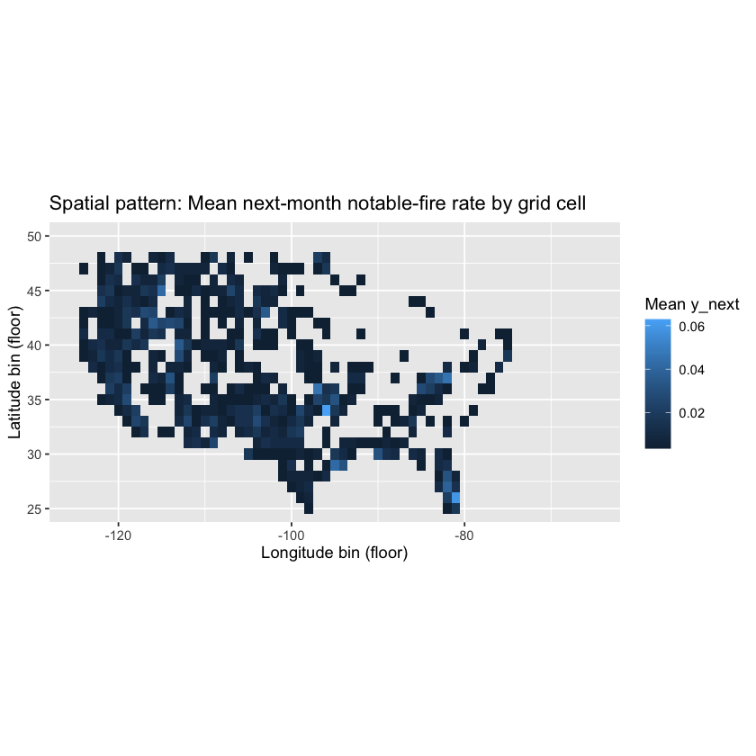

```r
eda_spatial <- panel %>%
  group_by(lat_bin, lon_bin) %>%
  summarise(fire_rate = mean(y_next), .groups = "drop")

ggplot(eda_spatial, aes(x = lon_bin, y = lat_bin, fill = fire_rate)) +
  coord_quickmap(xlim = c(-125, -65), ylim = c(25, 50)) +
  geom_tile() +
  labs(
    title = "Spatial pattern: Mean next-month notable-fire rate by grid cell",
    x = "Longitude bin (floor)",
    y = "Latitude bin (floor)",
    fill = "Mean y_next"
  )
```

### Interpretation

The spatial variability of the risk of notable fires in the next-month is depicted in this graph, where grid cells with a more intense blue color have more hot spots. Persistent hot areas are thought to be a reflection of regional variations in topography, vegetation, climate, and human activities that could affect the frequency of wildfires. Prediction location-specific base data needs several variables, including "lat_bin," "lon_bin," and "state".

### EDA Plot 2: Temporal pattern

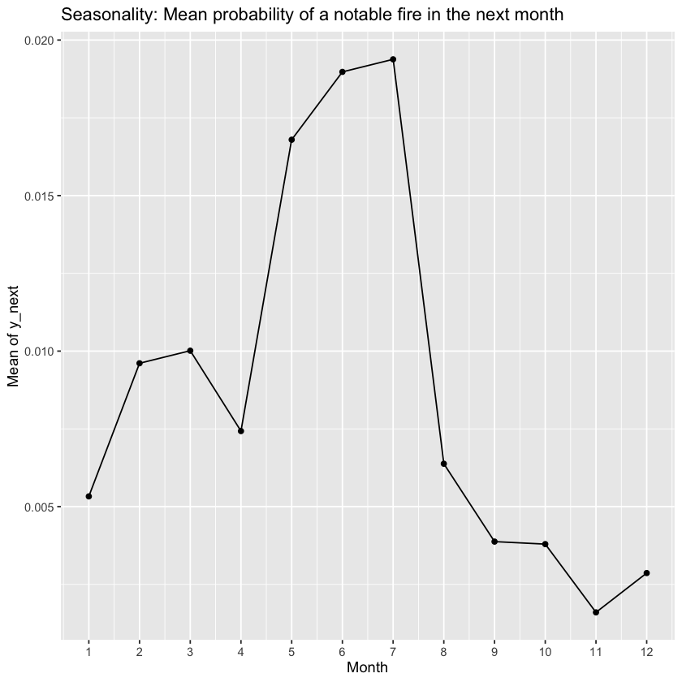

```r
eda_month <- panel %>%
  group_by(month) %>%
  summarise(mean_y_next = mean(y_next), .groups = "drop")

ggplot(eda_month, aes(x = month, y = mean_y_next)) +
  geom_line() +
  geom_point() +
  scale_x_continuous(breaks = 1:12) +
  labs(
    title = "Seasonality: Mean probability of a notable fire in the next month",
    x = "Month",
    y = "Mean of y_next"
  )
```

### Interpretation

This plot clearly shows seasonality in the next month notable fire risk, with some months having a higher fire probability than others. This pattern shows that wildfire has an annual cycle, not fixed all the time for a whole year. This suggests that seasonal patterns are important for prediction, which motivates the inclusion of cyclical month features such as `month_sin` and `month_cos`.

### EDA Plot 3: Recent fire activity and predict next month fire risk

To determine whether short-term wildfire history is predictive and to reduce losses, comparing the probability of notable fires next month across different levels of recent fire activity can be helpful. This directly motivates the inclusion of lagged fire-history predictors, such as `fire_roll12`.

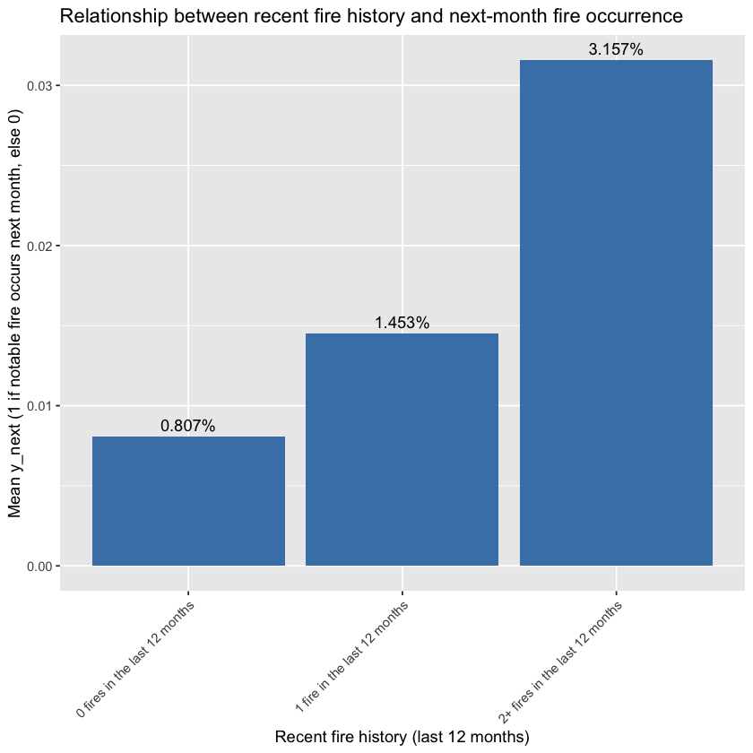

```r
lag_support <- panel %>%
  mutate(
    recent_fire_12m = fire_roll12,
    recent_fire_groups = case_when(
      recent_fire_12m == 0 ~ "0 fires in the last 12 months",
      recent_fire_12m == 1 ~ "1 fire in the last 12 months",
      recent_fire_12m >= 2 ~ "2+ fires in the last 12 months"
    ),
    recent_fire_groups = factor(
      recent_fire_groups,
      levels = c(
        "0 fires in the last 12 months",
        "1 fire in the last 12 months",
        "2+ fires in the last 12 months"
      )
    )
  ) %>%
  group_by(recent_fire_groups) %>%
  summarise(mean_y_next = mean(y_next), .groups = "drop")

ggplot(lag_support, aes(x = recent_fire_groups, y = mean_y_next)) +
    geom_bar(stat = "identity", fill = "steelblue") +
    geom_text(aes(label = scales::percent_format(accuracy = 0.001)(mean_y_next)), vjust = -0.5) +
  labs(
    title = "Relationship between recent fire history and next-month fire occurrence",
    x = "Recent fire history (last 12 months)",
    y = "Mean y_next (1 if notable fire occurs next month, else 0)"
  ) +
  theme(axis.text.x = element_text(angle = 45, hjust = 1))
```

### Interpretation

This plot shows that as the number of notable fires in the previous 12 months increases, the probability of a notable fire in the next month also increases. Grid-months with two or more notable fires in the last 12 months have the highest subsequent risk, with a next-month fire probability of 3.157%, compared with about 0.8% for grid-months with no recent fires. The idea is that inherent factors such as dry vegetation, local weather, and seasonal burning patterns are not quickly re-established after a burn, so the wildfire risk generally remains in the same area. This supports including `fire_roll12` as a predictor in the models.

## 3. Modeling

We fit at least **two** models:

1. **Baseline:** Logistic regression (interpretable benchmark)
2. **Model of choice:** Gradient boosted trees (XGBoost)

```r
model_df <- panel %>%
  mutate(y_next = factor(y_next, levels = c(0, 1))) %>%
  select(y_next, lat_bin, lon_bin, state,
         month_cos, month_sin, year,
         n_fires, fire_lag12, fire_roll3, fire_roll12, size_roll3, size_roll12)
```

There are 147576 grid-month observations in the final modeling dataset. The binary outcome is `y_next`, and the predictors include spatial variables:`lat_bin`, `lon_bin`, `state` , seasonal variables: `month_cos`, `month_sin`, `year`, and lagged fire-history variables: `n_fires`, `fire_lag12`, `fire_roll3`, `fire_roll12`, `size_roll3`, and `size_roll12`. These predictors can help capture geographic variation, seasonality, and short- to long-term wildfire persistence.

Logistic regression is used as the baseline model because it provides an interpretable benchmark for a binary prediction problem. The baseline model can be written as

$$ \text{logit}(p_{g,t}) = \beta_0 + \text{spatial terms} + \text{seasonal terms} + \text{fire-history terms}. $$

This baseline model is useful because it provides a clear metric for comparing models and shows how each prediction relates to the logarithmic probability that a notable fire will occur in the next month.

As a second example, we use XGBoost, a gradient-boosted decision tree technique that works particularly well with tabular data. Since the risk of wildfire can depend on nonlinear effects and interactions between geography, season, and recent burn history, XGBoost is a particularly interesting choice in this situation. For example, the effects of recent fires can vary by month or location, and a simple linear model would not be sufficient to capture these relationships. Consequently, XGBoost is a flexible alternative that more effectively identifies complex predictive patterns in the data.

XGBoost predicts notable wildfires next month by combining lots of decision trees, each one built on improves errors of the previous one.

## 4. Model Fitting and Validation

Validation respects the temporal structure via expanding window. For each fold:

- Train on years $\le t$
- Validate on year $t+1$ with $t\geq 3$

We report **AUC** for both models and include a diagnostic plot for AUC across time folds.

The expanding window approach is suitable for forecasting future wildfire risk because it preserves the temporal order of the data. In each fold, these models are trained on data from the all available data up (t) and tested on the next year (t+1), so as not to use any information about the future to predict future outcomes. This reduces temporal bias and more accurately reflects the real-world forecasting situation, where wildfire risk would be assessed only from the historical information available at the time.

```r
years_sorted <- sort(unique(model_df$year))
min_train_years <- 3

set.seed(123)

feat_formula <- y_next ~ lat_bin * lon_bin + state + month_cos + month_sin +
  year + n_fires + fire_lag12 + fire_roll3 + fire_roll12 + size_roll3 + size_roll12

fold_results <- tibble(
  train_end_year = years_sorted[min_train_years:(length(years_sorted) - 2)],
  valid_year = years_sorted[(min_train_years + 1):(length(years_sorted) - 1)]
) %>%
  mutate(
    auc_glm = map2_dbl(train_end_year, valid_year, function(tr_end, va_year) {
      train <- model_df %>% filter(year <= tr_end)
      valid <- model_df %>% filter(year == va_year)

      fit <- suppressWarnings(glm(feat_formula, data = train, family = binomial))
      p_hat <- predict(fit, newdata = valid, type = "response")

      as.numeric(pROC::auc(pROC::roc(response = valid$y_next, predictor = p_hat, quiet = TRUE)))
    }),

    auc_xgb = map2_dbl(train_end_year, valid_year, function(tr_end, va_year) {
      train <- model_df %>% filter(year <= tr_end)
      valid <- model_df %>% filter(year == va_year)

      new_data <- bind_rows(train, valid) %>%
        mutate(state = factor(state, levels = levels(model_df$state)))

      x_all <- model.matrix(feat_formula, data = new_data)[, -1, drop = FALSE]
      x_train <- x_all[seq_len(nrow(train)), , drop = FALSE]
      x_valid <- x_all[(nrow(train) + 1):nrow(new_data), , drop = FALSE]

      y_train <- as.numeric(train$y_next) - 1
      y_valid <- as.numeric(valid$y_next) - 1

      scale_pos_weight <- sum(y_train == 0) / sum(y_train == 1)

      dtrain <- xgb.DMatrix(data = x_train, label = y_train)
      dvalid <- xgb.DMatrix(data = x_valid, label = y_valid)

      xgb_model <- xgb.train(
        params = list(
          objective = "binary:logistic",
          eval_metric = "auc",
          booster = "gbtree",
          eta = 0.05,
          max_depth = 3,
          min_child_weight = 5,
          subsample = 0.7,
          colsample_bytree = 0.7,
          gamma = 1,
          lambda = 1,
          alpha = 1,
          scale_pos_weight = scale_pos_weight,
          nthread = 8
        ),
        data = dtrain,
        evals = list(train = dtrain, valid = dvalid),
        nrounds = 1000,
        early_stopping_rounds = 50,
        verbose = 0
      )

      p_hat_xgb <- predict(xgb_model, dvalid)
      as.numeric(pROC::auc(pROC::roc(response = valid$y_next, predictor = p_hat_xgb, quiet = TRUE)))
    })
  )

fold_results
```

A tibble: 20 × 4

| train_end_year <dbl> | valid_year <dbl> | auc_glm <dbl> | auc_xgb <dbl> |
| --- | --- | --- | --- |
| 1994 | 1995 | 0.6757262 | 0.7621110 |
| 1995 | 1996 | 0.7232376 | 0.8266525 |
| 1996 | 1997 | 0.7932319 | 0.8277607 |
| 1997 | 1998 | 0.7585188 | 0.8204390 |
| 1998 | 1999 | 0.6679481 | 0.7560544 |
| 1999 | 2000 | 0.7261246 | 0.7830484 |
| 2000 | 2001 | 0.7575094 | 0.8321265 |
| 2001 | 2002 | 0.7296244 | 0.7995419 |
| 2002 | 2003 | 0.7293333 | 0.8100115 |
| 2003 | 2004 | 0.6583030 | 0.8278201 |
| 2004 | 2005 | 0.6684603 | 0.7554878 |
| 2005 | 2006 | 0.6568261 | 0.7384594 |
| 2006 | 2007 | 0.6487039 | 0.7425210 |
| 2007 | 2008 | 0.6159752 | 0.7101698 |
| 2008 | 2009 | 0.6771861 | 0.7937769 |
| 2009 | 2010 | 0.6610666 | 0.7358487 |
| 2010 | 2011 | 0.6600808 | 0.7458857 |
| 2011 | 2012 | 0.6413855 | 0.7740807 |
| 2012 | 2013 | 0.7041008 | 0.8268040 |
| 2013 | 2014 | 0.7386696 | 0.8165091 |

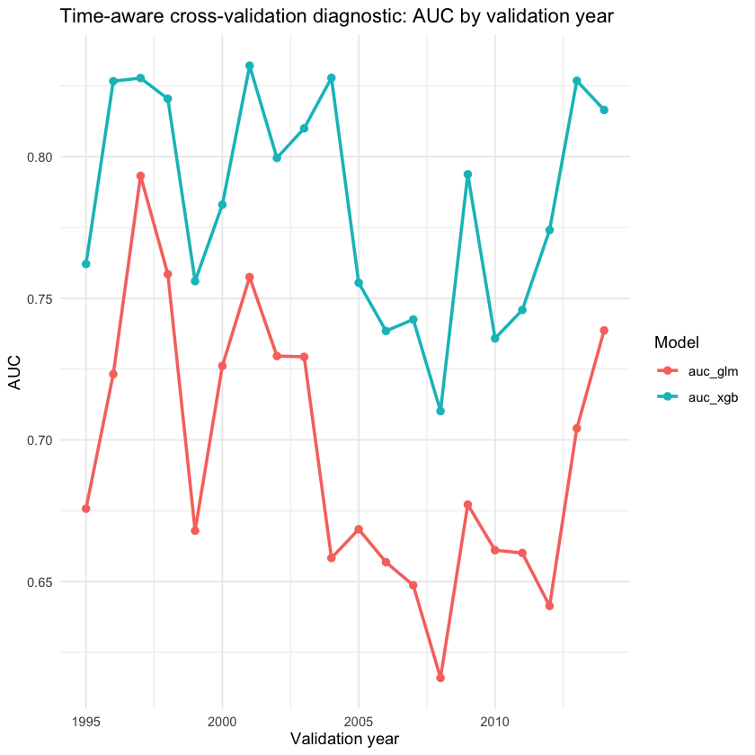

```r
fold_long <- fold_results %>%
  pivot_longer(
    cols = c(auc_glm, auc_xgb),
    names_to = "model",
    values_to = "auc"
  )

ggplot(fold_long, aes(x = valid_year, y = auc, color = model)) +
  geom_line(linewidth = 1) +
  geom_point(size = 2) +
  labs(
    title = "Time-aware cross-validation diagnostic: AUC by validation year",
    x = "Validation year",
    y = "AUC",
    color = "Model"
  ) +
  theme_minimal()
```

Because the output are highly imbalance, AUC is used as the primary evaluation metric. There are rarely any notable fires in the next month compared to the non-fire observations. Because a model might achieve high accuracy by forecasting largely zeros, this indicates that the overall accuracy is misleading. Higher-risk grid-months are ranked higher than lower-risk ones across various classification criteria by the algorithm, which is more visibly represented by AUC.

XGBoost has continually exceeded logistic regression on AUC metrics in previous years, showing that non-linear effects and interactions increase predictive power beyond a linear baseline. Furthermore, the differences across folds indicate that some fire seasons will inherently be more complex by nature than others. This outcome is in line with the earlier EDA finding that fire risk varies over time and is not constant between years.

### Average AUC across validation folds

On average, XGBoost has a higher AUC than logistic regression, which is consistent with the fold-by-fold comparison shown above.

```r
cat('Overall, XGBoost outperforms logistic regression in AUC by ',
    round(mean(fold_results$auc_xgb) / mean(fold_results$auc_glm) * 100, 2) - 100, "%", sep= '')
```

```
Overall, XGBoost outperforms logistic regression in AUC by 12.91%
```

```r
cat(
  "Average AUC: logistic regression = ",
  round(mean(fold_results$auc_glm), 3),
  ", XGBoost = ",
  round(mean(fold_results$auc_xgb), 3),
  ", absolute improvement = ",
  round(mean(fold_results$auc_xgb) - mean(fold_results$auc_glm), 4),
  sep = ""
)
```

```
Average AUC: logistic regression = 0.695, XGBoost = 0.784, absolute improvement = 0.0897
```

For easier interpretation, I refit a simpler logistic regression model without the `lat_bin * lon_bin` interaction. The table below summarizes the main effects of the predictors. This model is just for the coefficient and not part of the performance comparison. The table summarizes the main effects of predictors.

```r
glm_full <- glm(
  y_next ~ lat_bin + lon_bin + state +
    month_cos + month_sin + year +
    n_fires + fire_lag12 + fire_roll3 + fire_roll12 +
    size_roll3 + size_roll12,
  data = panel,
  family = binomial
)

coef_tbl <- summary(glm_full)$coefficients %>%
  as.data.frame() %>%
  tibble::rownames_to_column("term") %>%
  rename(
    estimate = Estimate,
    std_error = `Std. Error`,
    z_value = `z value`,
    p_value = `Pr(>|z|)`
  ) %>%
  filter(term != "(Intercept)") %>%
  filter(!grepl("^state", term)) %>%
  mutate(
    odds_ratio = exp(estimate),
    abs_z = abs(z_value),
    new_term = recode(term,
      month_cos = "Month in cosine",
      month_sin = "Month in sine",
      year = "Year",
      n_fires = "Number of fires this month",
      fire_lag12 = "Number of fires 12 months ago",
      fire_roll3 = "Rolling sum of fires in last 3 months",
      fire_roll12 = "Rolling sum of fires in last 12 months",
      size_roll3 = "Rolling sum of fire size in last 3 months",
      size_roll12 = "Rolling sum of fire size in last 12 months",
      lat_bin = "Latitude bin (floor)",
      lon_bin = "Longitude bin (floor)"
    )
  ) %>%
    arrange(desc(abs_z)) %>%
    select(new_term, estimate, odds_ratio,p_value) %>%
    slice(1:10)

coef_tbl
```

A data.frame: 10 × 4

| new_term <chr> | estimate <dbl> | odds_ratio <dbl> | p_value <dbl> |
| --- | --- | --- | --- |
| Month in cosine | -8.526607e-01 | 0.4262792 | 1.379780e-78 |
| Month in sine | 2.689769e-01 | 1.3086249 | 1.020616e-10 |
| Number of fires this month | 9.963442e-01 | 2.7083625 | 1.430013e-08 |
| Year | 1.759369e-02 | 1.0177494 | 1.672203e-05 |
| Rolling sum of fires in last 12 months | 2.601878e-01 | 1.2971736 | 9.524515e-05 |
| Number of fires 12 months ago | 5.398148e-01 | 1.7156891 | 4.307087e-04 |
| Rolling sum of fire size in last 3 months | -2.984781e-05 | 0.9999702 | 1.315324e-01 |
| Latitude bin (floor) | -2.367699e-02 | 0.9766011 | 1.663517e-01 |
| Rolling sum of fire size in last 12 months | 3.376546e-06 | 1.0000034 | 3.550338e-01 |
| Longitude bin (floor) | 9.807188e-03 | 1.0098554 | 4.141097e-01 |

In the baseline logistic regression, temporal factors and fire history are the strongest predictors. Specifically, the number of fires this month, the number of fires 12 months ago, and the rolling sum of fires in the last 12 months all have positive coefficients. This suggests that current and recent fire activity are associated with a higher risk of fire occurrence in the next month. These results are consistent with the EDA findings that wildfires are both seasonal and persistent.

## 5. Summary

### Data preprocessing and feature engineering

- Historical notable wildfire records were organized into a grid-by-month panel dataset, where each spatial grid cell is represented for every observed month.
- The prediction target is whether at least one notable wildfire will occur in a given grid cell during the following month.
- Because the positive outcome rate is only about 0.89%, the next-month prediction problem is highly imbalanced.
- Time-aware predictors were constructed from historical wildfire information, including seasonal structure and recent wildfire activity, so that only past information is used for prediction.

### Key insights from exploratory data analysis

- Wildfire risk is not spatially uniform. Some grid cells repeatedly appear as higher-risk locations, suggesting that regional and spatial factors are important for prediction.
- Clear seasonal patterns are present in wildfire occurrence, which supports the use of cyclical month features such as `month_sin` and `month_cos`.
- Recent wildfire history is informative: grid-months with more wildfire activity in the previous 12 months tend to have a higher probability of wildfire occurrence in the next month.
- Wildfire risk also changes across years, indicating that the prediction task is not equally easy across all time periods.

### Modeling takeaway

- Model evaluation was conducted using expanding-window cross-validation to preserve temporal order and reflect a realistic forecasting setting.
- A baseline logistic regression model was compared with a nonlinear XGBoost model across validation folds.
- Both models show predictive ability, but XGBoost performs better overall.
- The mean validation AUC is **0.784** for XGBoost and **0.695** for logistic regression, corresponding to an absolute improvement of **0.089 AUC points**.
- These results suggest that nonlinear relationships and interactions among location, seasonality, and recent wildfire activity improve predictive performance beyond a linear baseline.

### Limitations and future work

- This study is based on a sample of wildfire records rather than a complete historical archive of wildfire events.
- The 1° × 1° spatial grid is relatively coarse and may not represent local wildfire conditions accurately.
- The predictors are derived mainly from wildfire incident history and do not include other potentially important factors such as climate, temperature, vegetation, drought conditions, or human activity.
- Future work could improve performance by incorporating richer environmental variables and using finer spatial resolution.

### Reference:

(2023, November 28). National Interagency Predictive Services Handbook - 2023. National Interagency Fire Center (.gov). Retrieved November 28, 2023, from https://www.nifc.gov/sites/default/files/NICC/2-Predictive%20Services/National%20Interagency%20Predictive%20Services%20Handbook%202023.pdf

Chen, T. (n.d.). XGBoost: A Scalable Tree Boosting System. ArXiv. https://arxiv.org/pdf/1603.02754

(2005, December 19). An introduction to ROC analysis. ScienceDirect. Retrieved December 19, 2005, from https://www.sciencedirect.com/science/article/pii/S016786550500303X?via%3Dihub

(2023, May 5). 10 Tips to Prevent Wildfires. U.S. Department of the Interior. Retrieved May 15, 2023, from https://www.doi.gov/blog/10-tips-prevent-wildfires

Hyndman , R. J. J., & Athanasopoulos, G. (2026, March 9). 5.10 Time series cross-validation. Forecasting: Principles and Practice (3rd ed). Retrieved March 9, 2026, from https://otexts.com/fpp3/tscv.html

(n.d.). What Causes Wildfires? Frontline Wildfire Defense. https://www.frontlinewildfire.com/wildfire-news-and-resources/what-causes-wildfires/